# Final Project

Wenjuan Bian

2023-11-15

### Introduction

**In their 2014 study, Adewara and Mbata conducted a comprehensive analysis of three resampling techniques - Bootstrap Estimation (BE), Jackknife Estimation (JE), and K-Repeated Jackknife Estimation (KJE) - for estimating survival probabilities based on an exponential lifetime distribution. This paper aims to assess the performance of these methods by comparing their mean square error (MSE) and mean percentage error (MPE) using simulated data. Our project was to replicate their study, applying our theoretical knowledge practically and validate the original findings.**

**However, our replication efforts using R-Software uncovered notable inconsistencies. While we successfully replicated the results in Tables 1, 2, and 3, our findings for Table 4 significantly contrasted with the paper’s claims and presented data. In the original paper, Tables 4 and 5 display identical values for the Jackknife and K-Repeated Jackknife methods, which does not support the conclusion that the K-Repeated Jackknife method is superior in performance and is more effective in reducing MSE. This contradiction is a significant point of inquiry, as it suggests potential issues in either the methodology, data analysis, or reporting within the original study.**

**Recognizing these inconsistencies, we reached out to the authors for clarification but have not received a meaningful response. Despite an initial reply stating, “I will look into this and get back to you,” no further explanation or response has been provided by today (11/07/2023). This lack of feedback underscores the challenges and limitations often encountered in academic research, particularly when addressing potential errors or oversights in published work.**

**Our project not only highlights the importance of replication in scientific research but also underscores the necessity of addressing inconsistencies in published studies. The discrepancies we discovered call for a thorough re-examination of the original paper’s methodologies and conclusions. As we continue to seek clarification from the authors, our work contributes to the broader discourse on the reliability and validation of statistical research methods.**

### Data in the paper

```r
size <- c(10, 10, 10, 10, 20, 20, 20, 20, 30, 30, 30, 30)
lambda <- c(0.5, 1.0, 1.5, 2.0, 0.5, 1.0, 1.5, 2.0, 0.5, 1.0, 1.5, 2.0)



A1 <- matrix(
  c(
    0.38672500, 2.27994293, 0.20192160, 0.01058359,
    0.11665480, 0.71411938, 0.48301090, 2.51951031,
    0.12661390, 0.75298901, 0.12473380, 1.94495769,
    4.42286640, 2.19289233, 1.99662440, 0.67531853,
    2.00704600, 0.04442099, 0.67780240, 1.05647689,
    2.34689070, 0.35021824, 0.75981590, 0.01373747,
    0.86211020, 1.01674933, 0.87373650, 0.08979746,
    1.03118540, 0.82205630, 0.21055390, 0.73813115,
    12.74339800, 0.02251542, 1.47164790, 0.07333057,
    1.96347260, 1.01602885, 0.52020820, 1.38869338
  ),
  nrow = 10,
  byrow = TRUE
)

A2 <- matrix(
  c(
    2.62129072, 0.13858938, 0.61025422, 0.20816883,
    3.66009415, 0.23677409, 1.39562321, 0.10508682,
    0.28671927, 0.65882621, 1.64585069, 0.16343073,
    0.53614812, 2.03913598, 1.11779841, 4.47429656,
    1.67262059, 3.07310425, 0.64918675, 0.31910786,
    0.08521250, 0.85047816, 0.05778008, 0.21707275,
    0.84341716, 0.93587816, 0.04898416, 0.04360368,
    1.87988871, 3.97283307, 0.12098188, 0.11505109,
    3.13213741, 1.91406287, 0.55509004, 0.24578897,
    6.82508233, 1.04861761, 0.19238185, 1.05875641,
    0.02900937, 0.03350444, 0.26953211, 0.00355591,
    1.74900498, 1.30175357, 0.01133644, 0.05922794,
    1.24431388, 1.52538027, 0.28231025, 0.20815442,
    1.12438751, 0.06504098, 2.50193518, 1.48214568,
    1.02901637, 1.90192968, 0.52524965, 0.89694421,
    2.19818977, 0.71117769, 0.20890800, 1.53327300,
    5.75705560, 2.66119925, 0.12742349, 1.11055824,
    0.67605113, 1.38839741, 0.09933566, 0.81368075,
    0.79778248, 0.30239189, 0.08220231, 0.46919296,
    1.06989471, 0.00054309, 0.22447181, 1.03504680
  ),
  nrow = 20,
  byrow = TRUE
)

A3 <- matrix(
  c(
    1.09871091, 0.17085314, 0.24591320, 0.03006484,
    1.30597223, 0.31266839, 0.78554402, 0.01316790,
    0.43742079, 0.21960578, 0.26193004, 0.08580695,
    0.57034193, 1.09603105, 0.07651001, 0.06684230,
    1.02475744, 0.54796524, 0.29620540, 0.75349995,
    1.53172531, 0.13561858, 0.58560088, 0.56383185,
    0.57173448, 0.46805576, 0.56401687, 0.10014385,
    3.18835121, 0.58675535, 0.41054238, 0.39468972,
    1.01423546, 0.41116558, 1.42498655, 0.26076246,
    0.05104055, 3.42353290, 0.03212381, 0.38563026,
    2.99399940, 1.09817464, 0.19768464, 0.96558979,
    2.95112802, 0.35962685, 0.24295821, 0.27934118,
    4.74244122, 1.98862082, 0.16056365, 0.01547041,
    0.04628853, 1.11964839, 0.24140637, 0.34343548,
    5.35809191, 0.48539163, 0.06956623, 0.80092480,
    4.26185504, 1.09365222, 1.49188159, 1.49780414,
    0.04367701, 0.73949713, 0.22345808, 0.90349970,
    0.05851474, 0.34345758, 1.56937093, 0.18701462,
    0.46455153, 0.29243694, 0.59195204, 0.00288255,
    0.09371455, 0.25904558, 0.42176436, 0.74330912,
    2.96970220, 1.79180600, 1.11983745, 0.25455636,
    0.54133977, 0.01809066, 0.28416911, 0.81341579,
    1.29204462, 2.94010580, 0.65638599, 0.10230827,
    0.02923826, 0.79327459, 0.12515747, 2.24807427,
    2.28724168, 1.13577062, 2.26479793, 0.08718112,
    3.62406597, 0.05051664, 1.73361763, 1.15865739,
    0.55831489, 0.53652729, 0.36225826, 0.02484439,
    4.24494133, 1.08361205, 1.41035274, 0.48756216,
    0.13192788, 0.25488727, 0.93471466, 0.25596331,
    0.39449119, 1.92176066, 0.27655395, 0.09251206
  ),
  nrow = 30,
  byrow = TRUE
)

data.paper <- list(A1[,1], A1[,2], A1[,3], A1[,4], A2[,1], A2[,2], A2[,3], A2[,4],A3[,1], A3[,2], A3[,3], A3[,4])

# data.paper
```

### Table 2

```r
library(dplyr)
```

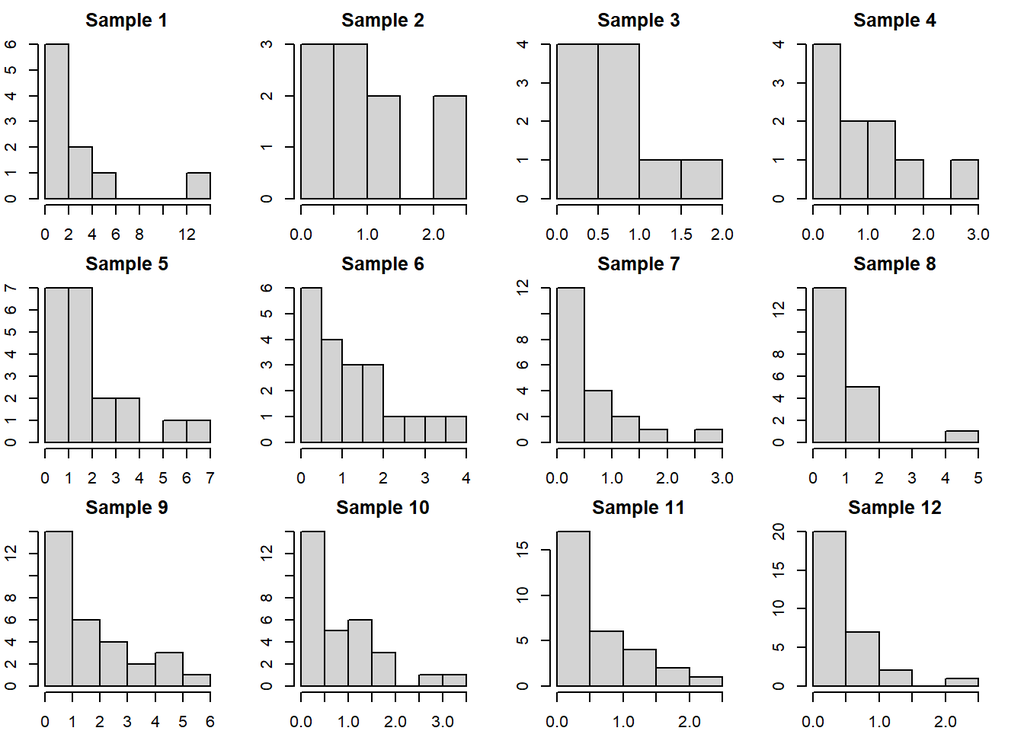

```r
library(purrr)


par(mfrow = c(3, 4), mar = c(2, 2, 2, 2))
for (i in 1:length(data.paper)) {
  hist(data.paper[[i]], main = paste("Sample", i), xlab = "Value", ylab = "Frequency")
}
```

```r
calculate_stats <- function(sample) {
  c(mean = mean(sample), median = median(sample), sd = sd(sample))
}


stats <- lapply(data.paper, calculate_stats)


df.stats <- cbind(N= size, lambda=lambda, do.call(rbind, stats))
rownames(df.stats) <- paste("Sample", 1:length(data.paper))

print(df.stats)
```

```
##            N lambda      mean    median        sd
## Sample 1  10    0.5 2.6006963 1.4973290 3.7961509
## Sample 2  10    1.0 0.9211933 0.7875227 0.7792381
## Sample 3  10    1.5 0.7320056 0.5990053 0.5961606
## Sample 4  10    2.0 0.8510537 0.7067248 0.8785794
## Sample 5  20    0.5 1.8608658 1.1843507 1.8059576
## Sample 6  20    1.0 1.2379809 0.9922479 1.0967927
## Sample 7  20    1.5 0.5363318 0.2470020 0.6540289
## Sample 8  20    2.0 0.7281072 0.2824484 1.0112265
## Sample 9  30    0.5 1.5960620 1.0194965 1.6278563
## Sample 10 30    1.0 0.8559385 0.5422463 0.8296031
## Sample 11 30    1.5 0.6353941 0.3864003 0.5880883
## Sample 12 30    2.0 0.4639596 0.2700518 0.5150784
```

### Table 3 and 4

```r
library(boot)
sur.f <- function(t, lambda) {
  exp(-lambda * t)
}

boot.f <- function(data, indices) {
   sample1 <- data[indices]
   theta.b <- mean(sample1)
   return(theta.b)
}

# Create empty lists/vectors to store the results
boot.re <- numeric(length(data.paper))
boot.mse <- numeric(length(data.paper))
boot.sur <- numeric(length(data.paper))
boot.mpe <- numeric(length(data.paper))

# Iterate over each dataset in data.paper and apply boot.f
for (i in 1:length(data.paper)) {
  boot.obj <- boot(data = data.paper[[i]], statistic = boot.f, R = 2000)
  y <-boot.obj$t
  boot.re[i] <- mean(y)
  boot.sur[i] <- mean(sur.f(data.paper[[i]], lambda = 1 / boot.re[i]))
  boot.mse[i] <- sum((y - boot.re[i])^2) / (length(y) - 1)
  boot.mpe[i] <- mean(abs(y-boot.re[i]))/boot.re[i]
}

boot.results <- data.frame(Sample = 1:length(data.paper), Mean = boot.sur, MSE = boot.mse, MPE=boot.mpe)

# Jackknife and Repeated jackknife
jk.re.an <- function(data) {

  jk.re1 <- function(data1) {
    n <- length(data1)
    jk1 <- numeric(n)

    for (i in 1:n) {
      sample1 <- data1[-i]
      jk1[i] <- mean(sample1)
    }
    return(jk1)
  }


  jk.ret1 <- jk.re1(data)

  mean.jk <- mean(jk.ret1)
  jk.1f <- mean(sur.f(data, 1 / mean.jk))
  mse.jk1 <- sum((jk.ret1 - mean.jk)^2) / (length(jk.ret1) - 1)
  mpe.jk1 <- mean(abs(jk.ret1-mean.jk))/mean.jk

  #Repeated k jackknife

  k=length(data)

  jk.results <- vector("list", k)

  jk.results[[1]] <- jk.ret1

  for (i in 2:k) {
    jk.results[[i]] <- jk.re1(jk.results[[i - 1]])
  }

jkre <- unlist(jk.results)
length.jkre <- length(jkre)
jkre.mean <- mean(jkre)
jkre.mse <- var(jkre)/(length(jk.results)-1) #sum((jkre - jkre.mean)^2) / ((length(jkre) - 1)*(length(jkre)))  #var(jkre)
thetahatmse <- var(jkre)/(length(jk.results)-1)
thetahatmpe <- mean(abs(jkre-jkre.mean)/jkre.mean)
jkrkf <- mean(sur.f(data, 1/jkre.mean))
return(list(jk.1f=jk.1f, mse.jk1=mse.jk1, mpe.jk1=mpe.jk1,jkrkf = jkrkf, jkre.mse = jkre.mse, length.jkre= length.jkre,thetahatmse=thetahatmse, thetahatmpe=thetahatmpe))
}


jk.re.results <- lapply(data.paper, jk.re.an)



jk.sur <- sapply(jk.re.results, function(x) x$jk.1f)
mse.jk <-  sapply(jk.re.results, function(x) x$mse.jk1)
mpe.jk <-  sapply(jk.re.results, function(x) x$mpe.jk1)
jk.re.sur <- sapply(jk.re.results, function(x) x$jkrkf)
mse.jk.re <- sapply(jk.re.results, function(x) x$jkre.mse)
jk.re.length <- sapply(jk.re.results, function(x) x$length.jkre)
jk.re.thetamse <- sapply(jk.re.results, function(x) x$thetahatmse)
jk.re.thetampe<- sapply(jk.re.results, function(x) x$thetahatmpe)
jk.re.mpe <- jk.re.thetampe
```

### table 3

```r
df2 <- data.frame(
  SampleSize = size,
  Lambda = lambda,
  Bootstrap = boot.results[,2],
  Jackknife = jk.sur,
  JackknifeRe = jk.re.sur
  )

df2
```

```
##    SampleSize Lambda Bootstrap Jackknife JackknifeRe
## 1          10    0.5 0.5711603 0.5688799   0.5688799
## 2          10    1.0 0.4763098 0.4764569   0.4764569
## 3          10    1.5 0.4610719 0.4613285   0.4613285
## 4          10    2.0 0.5300484 0.5299378   0.5299378
## 5          20    0.5 0.4894883 0.4917777   0.4917777
## 6          20    1.0 0.4914196 0.4902400   0.4902400
## 7          20    1.5 0.5442241 0.5449304   0.5449304
## 8          20    2.0 0.5567579 0.5535801   0.5535801
## 9          30    0.5 0.5261816 0.5274456   0.5274456
## 10         30    1.0 0.4923180 0.4918826   0.4918826
## 11         30    1.5 0.4913832 0.4910998   0.4910998
## 12         30    2.0 0.5279396 0.5281186   0.5281186
```

```r
# Print the data frame
df2
```

```
##    SampleSize Lambda Bootstrap Jackknife JackknifeRe
## 1          10    0.5 0.5711603 0.5688799   0.5688799
## 2          10    1.0 0.4763098 0.4764569   0.4764569
## 3          10    1.5 0.4610719 0.4613285   0.4613285
## 4          10    2.0 0.5300484 0.5299378   0.5299378
## 5          20    0.5 0.4894883 0.4917777   0.4917777
## 6          20    1.0 0.4914196 0.4902400   0.4902400
## 7          20    1.5 0.5442241 0.5449304   0.5449304
## 8          20    2.0 0.5567579 0.5535801   0.5535801
## 9          30    0.5 0.5261816 0.5274456   0.5274456
## 10         30    1.0 0.4923180 0.4918826   0.4918826
## 11         30    1.5 0.4913832 0.4910998   0.4910998
## 12         30    2.0 0.5279396 0.5281186   0.5281186
```

### table 4

```r
df3 <- data.frame(
  SampleSize = size,
  Lambda = lambda,
  Bootstrap = boot.results[,3],
  Jackknife = mse.jk,
  JackknifeRe = mse.jk.re
)

df3
```

```
##    SampleSize Lambda   Bootstrap    Jackknife  JackknifeRe
## 1          10    0.5 1.291648236 0.1779106373 1.819541e-03
## 2          10    1.0 0.057181645 0.0074964448 7.666819e-05
## 3          10    1.5 0.031491751 0.0043877462 4.487468e-05
## 4          10    2.0 0.069757120 0.0095296511 9.746234e-05
## 5          20    0.5 0.151923761 0.0090345787 2.270595e-05
## 6          20    1.0 0.057916643 0.0033322834 8.374786e-06
## 7          20    1.5 0.020045212 0.0011849137 2.977958e-06
## 8          20    2.0 0.049415782 0.0028326288 7.119041e-06
## 9          30    0.5 0.083794068 0.0031509108 3.509079e-06
## 10         30    1.0 0.022800519 0.0008183606 9.113847e-07
## 11         30    1.5 0.011054816 0.0004112341 4.579796e-07
## 12         30    2.0 0.008512397 0.0003154647 3.513240e-07
```

### table 5

```r
df4 <- data.frame(
  SampleSize = size,
  Lambda = lambda,
  Bootstrap = boot.results[,3],
  Jackknife = mpe.jk,
  JackknifeRe = jk.re.mpe
  )
df4
```

```
##    SampleSize Lambda   Bootstrap  Jackknife  JackknifeRe
## 1          10    0.5 1.291648236 0.10223648 0.0115016042
## 2          10    1.0 0.057181645 0.06804798 0.0076553976
## 3          10    1.5 0.031491751 0.06599229 0.0074241326
## 4          10    2.0 0.069757120 0.09153159 0.0102973039
## 5          20    0.5 0.151923761 0.03690325 0.0019476713
## 6          20    1.0 0.057916643 0.03671500 0.0019377359
## 7          20    1.5 0.020045212 0.04633243 0.0024453228
## 8          20    2.0 0.049415782 0.04756272 0.0025102547
## 9          30    0.5 0.083794068 0.02975887 0.0010273897
## 10         30    1.0 0.022800519 0.02491690 0.0008602264
## 11         30    1.5 0.011054816 0.02546179 0.0008790379
## 12         30    2.0 0.008512397 0.02889973 0.0009977289
```